# The metaSEM package: A Brief Introduction

Mike Cheung

Mar 2023

# Introduction

- The [metaSEM](https://github.com/mikewlcheung/metasem) package (Cheung, 2015)[^1] conducts meta-analyses using a structural equation modeling (SEM) framework. It uses the [OpenMx](https://openmx.ssri.psu.edu/), [lavaan](https://lavaan.ugent.be/), and semPlot packages at the backend.
- The R code and the relevant files of this presentation are available at https://github.com/mikewlcheung/ESMARConf2023.

# MASEM

- Meta-analytic structural equation modeling (MASEM) is a statistical approach combining the advantages of both meta-analysis and SEM for fitting structural equation models on a pool of correlation matrices (Cheung, 2014[^2], 2015[^3], 2019[^4]; Cheung & Chan, 2005[^5], 2009[^6]; Cheung & Cheung, 2016[^7]; Cheung & Hafdahl, 2016[^8]).
- We illustrate the procedures with a meta-analysis of the theory of planned behavior (Scalco et al., 2017[^9]).
- The variables are `ATT` (attitude), `SN` (subjective norm), `PBC` (perceived behavior control), `BI` (behavioral intention), and `BEH` (behavior).

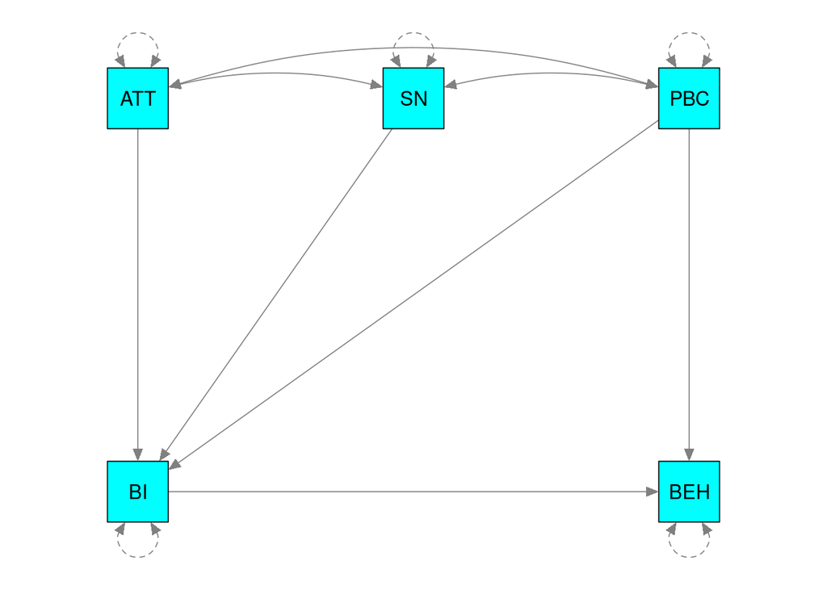

## Data checking

- The primary data are a list of correlation matrices and their sample sizes.

```r
library(metaSEM)

## See help(Scalco17) for the information
## Show the first few correlation matrices
head(Scalco17$data, n=3)
```

```
## $`Al-Swidi et al., 2014`
##       ATT    SN   PBC    BI BEH
## ATT 1.000 0.562 0.180 0.798  NA
## SN  0.562 1.000 0.314 0.696  NA
## PBC 0.180 0.314 1.000 0.216  NA
## BI  0.798 0.696 0.216 1.000  NA
## BEH    NA    NA    NA    NA  NA
##
## $`Arvola et al., 2008 (Study A from IT)`
##      ATT   SN  PBC   BI BEH
## ATT 1.00 0.69 0.44 0.73  NA
## SN  0.69 1.00 0.46 0.62  NA
## PBC 0.44 0.46 1.00 0.41  NA
## BI  0.73 0.62 0.41 1.00  NA
## BEH   NA   NA   NA   NA  NA
##
## $`Arvola et al., 2008 (Study A from UK)`
##      ATT   SN  PBC   BI BEH
## ATT 1.00 0.52 0.22 0.60  NA
## SN  0.52 1.00 0.28 0.56  NA
## PBC 0.22 0.28 1.00 0.31  NA
## BI  0.60 0.56 0.31 1.00  NA
## BEH   NA   NA   NA   NA  NA
```

```r
## Sample sizes
Scalco17$n
```

```
##  [1]  184  202  270  200  202  270  200  320  501  499  137  207  755  482  144
## [16]  944  547  261 2905  456  220  389 1054
```

```r
## Extract the variable names for future use
(obs.variables <- colnames(Scalco17$data[[1]]))
```

```
## [1] "ATT" "SN"  "PBC" "BI"  "BEH"
```

```r
## Display the numbers of studies
## There are fewer studies on BEH.
pattern.na(Scalco17$data, show.na=FALSE)
```

```
##     ATT SN PBC BI BEH
## ATT  23 22  22 23   6
## SN   22 23  22 23   6
## PBC  22 22  23 23   6
## BI   23 23  23 23   6
## BEH   6  6   6  6   6
```

```r
## Display the sample sizes
pattern.n(Scalco17$data, Scalco17$n)
```

```
##       ATT    SN   PBC    BI  BEH
## ATT 11349 10893 10893 11349 6223
## SN  10893 11349 10893 11349 6223
## PBC 10893 10893 11349 11349 6223
## BI  11349 11349 11349 11349 6223
## BEH  6223  6223  6223  6223 6223
```

## Two-Stage Structural Equation Modeling (TSSEM)

### Stage 1 analysis: Random-effects model

- The first stage of analysis is to combine the correlation matrices:
  - `Intercept1` to `Intercept10` are the average correlation coefficients.
  - `Tau2_1_1` to `Tau2_10_10` are the variances of the random effects.

```r
## method="FEM": fixed-effects model
## method="REM": random-effects model
## RE.type="Diag": random-effects are independent
random1 <- tssem1(Scalco17$data, Scalco17$n, method="REM", RE.type="Diag")
summary(random1)
```

```
##
## Call:
## meta(y = ES, v = acovR, RE.constraints = Diag(paste0(RE.startvalues,
##     "*Tau2_", 1:no.es, "_", 1:no.es)), RE.lbound = RE.lbound,
##     I2 = I2, model.name = model.name, suppressWarnings = TRUE,
##     silent = silent, run = run)
##
## 95% confidence intervals: z statistic approximation (robust=FALSE)
## Coefficients:
##               Estimate  Std.Error     lbound     ubound z value  Pr(>|z|)
## Intercept1   0.4124050  0.0400593  0.3338902  0.4909199 10.2949 < 2.2e-16 ***
## Intercept2   0.2529692  0.0304057  0.1933752  0.3125633  8.3198 < 2.2e-16 ***
## Intercept3   0.5956740  0.0295998  0.5376596  0.6536885 20.1243 < 2.2e-16 ***
## Intercept4   0.4253957  0.0449727  0.3372508  0.5135405  9.4590 < 2.2e-16 ***
## Intercept5   0.2358014  0.0231541  0.1904201  0.2811827 10.1840 < 2.2e-16 ***
## Intercept6   0.4866840  0.0354648  0.4171744  0.5561937 13.7230 < 2.2e-16 ***
## Intercept7   0.3656798  0.0484960  0.2706294  0.4607303  7.5404 4.685e-14 ***
## Intercept8   0.3210878  0.0266362  0.2688819  0.3732937 12.0546 < 2.2e-16 ***
## Intercept9   0.3080911  0.0572894  0.1958059  0.4203762  5.3778 7.540e-08 ***
## Intercept10  0.5290901  0.0620923  0.4073915  0.6507887  8.5210 < 2.2e-16 ***
## Tau2_1_1     0.0328381  0.0107167  0.0118338  0.0538423  3.0642  0.002182 **
## Tau2_2_2     0.0175623  0.0060606  0.0056837  0.0294410  2.8978  0.003758 **
## Tau2_3_3     0.0188921  0.0059586  0.0072134  0.0305708  3.1705  0.001522 **
## Tau2_4_4     0.0111905  0.0068616 -0.0022580  0.0246391  1.6309  0.102915
## Tau2_5_5     0.0089297  0.0036388  0.0017977  0.0160617  2.4540  0.014128 *
## Tau2_6_6     0.0271606  0.0085329  0.0104364  0.0438849  3.1830  0.001457 **
## Tau2_7_7     0.0130561  0.0083253 -0.0032611  0.0293734  1.5682  0.116823
## Tau2_8_8     0.0138039  0.0047983  0.0043994  0.0232085  2.8768  0.004017 **
## Tau2_9_9     0.0186366  0.0109737 -0.0028715  0.0401447  1.6983  0.089453 .
## Tau2_10_10   0.0225151  0.0133137 -0.0035793  0.0486095  1.6911  0.090814 .
## ---
## Signif. codes:  0 '***' 0.001 '**' 0.01 '*' 0.05 '.' 0.1 ' ' 1
##
## Q statistic on the homogeneity of effect sizes: 2848.457
## Degrees of freedom of the Q statistic: 149
## P value of the Q statistic: 0
##
## Heterogeneity indices (based on the estimated Tau2):
##                               Estimate
## Intercept1: I2 (Q statistic)    0.9545
## Intercept2: I2 (Q statistic)    0.9068
## Intercept3: I2 (Q statistic)    0.9591
## Intercept4: I2 (Q statistic)    0.8926
## Intercept5: I2 (Q statistic)    0.8228
## Intercept6: I2 (Q statistic)    0.9599
## Intercept7: I2 (Q statistic)    0.8973
## Intercept8: I2 (Q statistic)    0.8915
## Intercept9: I2 (Q statistic)    0.9255
## Intercept10: I2 (Q statistic)   0.9631
##
## Number of studies (or clusters): 23
## Number of observed statistics: 159
## Number of estimated parameters: 20
## Degrees of freedom: 139
## -2 log likelihood: -156.9808
## OpenMx status1: 0 ("0" or "1": The optimization is considered fine.
## Other values may indicate problems.)
```

```r
## Extract the fixed-effects estimates
(est_fixed <- coef(random1, select="fixed"))
```

```
##  Intercept1  Intercept2  Intercept3  Intercept4  Intercept5  Intercept6
##   0.4124050   0.2529692   0.5956740   0.4253957   0.2358014   0.4866840
##  Intercept7  Intercept8  Intercept9 Intercept10
##   0.3656798   0.3210878   0.3080911   0.5290901
```

```r
## It may not be easy to read the above estimates.
## We may convert the estimated vector to a symmetrical matrix
## where the diagonals are fixed at 1 (for a correlation matrix)
averageR <- vec2symMat(est_fixed, diag=FALSE)
dimnames(averageR) <- list(obs.variables, obs.variables)
averageR
```

```
##           ATT        SN       PBC        BI       BEH
## ATT 1.0000000 0.4124050 0.2529692 0.5956740 0.4253957
## SN  0.4124050 1.0000000 0.2358014 0.4866840 0.3656798
## PBC 0.2529692 0.2358014 1.0000000 0.3210878 0.3080911
## BI  0.5956740 0.4866840 0.3210878 1.0000000 0.5290901
## BEH 0.4253957 0.3656798 0.3080911 0.5290901 1.0000000
```

```r
## Get the estimated variances of the random effects
coef(random1, select = "random")
```

```
##   Tau2_1_1   Tau2_2_2   Tau2_3_3   Tau2_4_4   Tau2_5_5   Tau2_6_6   Tau2_7_7
## 0.03283809 0.01756235 0.01889211 0.01119053 0.00892974 0.02716065 0.01305611
##   Tau2_8_8   Tau2_9_9 Tau2_10_10
## 0.01380395 0.01863659 0.02251505
```

```r
## Alternative approach to get the full variance component of the random effects
VarCorr(random1)
```

```
##             [,1]       [,2]       [,3]       [,4]       [,5]       [,6]
##  [1,] 0.03283809 0.00000000 0.00000000 0.00000000 0.00000000 0.00000000
##  [2,] 0.00000000 0.01756235 0.00000000 0.00000000 0.00000000 0.00000000
##  [3,] 0.00000000 0.00000000 0.01889211 0.00000000 0.00000000 0.00000000
##  [4,] 0.00000000 0.00000000 0.00000000 0.01119053 0.00000000 0.00000000
##  [5,] 0.00000000 0.00000000 0.00000000 0.00000000 0.00892974 0.00000000
##  [6,] 0.00000000 0.00000000 0.00000000 0.00000000 0.00000000 0.02716065
##  [7,] 0.00000000 0.00000000 0.00000000 0.00000000 0.00000000 0.00000000
##  [8,] 0.00000000 0.00000000 0.00000000 0.00000000 0.00000000 0.00000000
##  [9,] 0.00000000 0.00000000 0.00000000 0.00000000 0.00000000 0.00000000
## [10,] 0.00000000 0.00000000 0.00000000 0.00000000 0.00000000 0.00000000
##             [,7]       [,8]       [,9]      [,10]
##  [1,] 0.00000000 0.00000000 0.00000000 0.00000000
##  [2,] 0.00000000 0.00000000 0.00000000 0.00000000
##  [3,] 0.00000000 0.00000000 0.00000000 0.00000000
##  [4,] 0.00000000 0.00000000 0.00000000 0.00000000
##  [5,] 0.00000000 0.00000000 0.00000000 0.00000000
##  [6,] 0.00000000 0.00000000 0.00000000 0.00000000
##  [7,] 0.01305611 0.00000000 0.00000000 0.00000000
##  [8,] 0.00000000 0.01380395 0.00000000 0.00000000
##  [9,] 0.00000000 0.00000000 0.01863659 0.00000000
## [10,] 0.00000000 0.00000000 0.00000000 0.02251505
```

### Stage 2 analysis: Structural equation model

- Structural equation models can be specified in [lavaan syntax](https://lavaan.ugent.be/tutorial/syntax1.html). As the metaSEM package uses [the RAM specification](https://bookdown.org/MathiasHarrer/Doing_Meta_Analysis_in_R/sem.html), we may convert the lavaan model to RAM via the `lavaan2RAM` function.

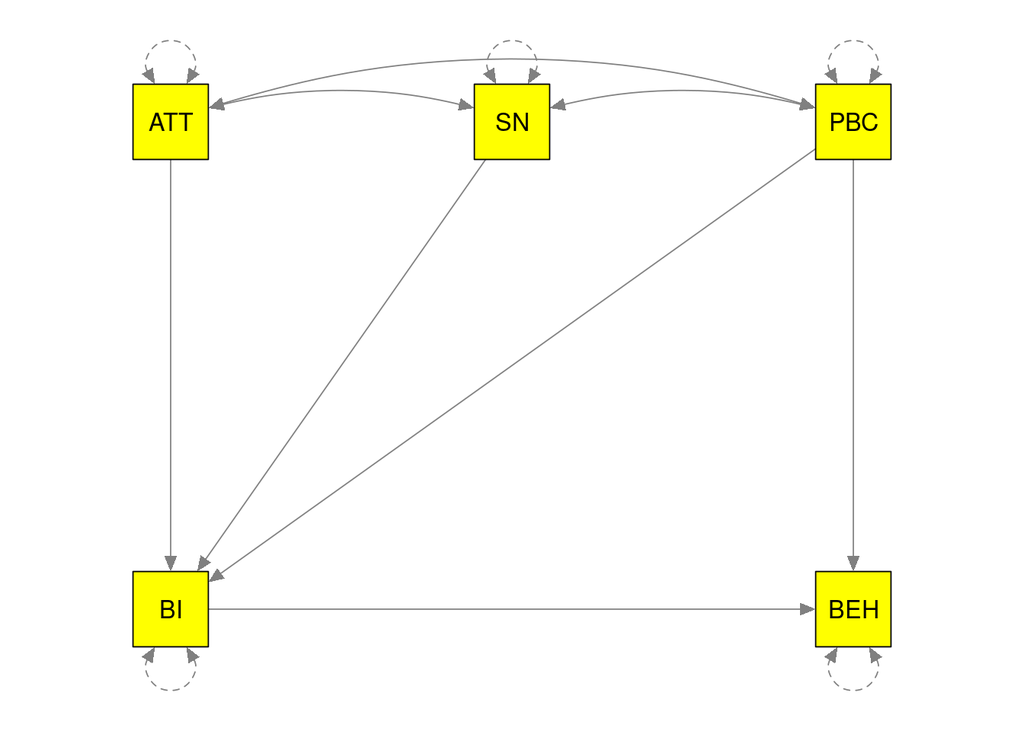

```r
model1 <- "## Path model
          BI ~ ATT + SN + PBC
          BEH ~ BI + PBC

          ## Fix the variances of the predictors at 1 as variables are standardized.
          ATT ~~ 1*ATT
          SN ~~ 1*SN
          PBC ~~ 1*PBC

          ## Allow the predictors correlated
          ATT ~~ SN
          ATT ~~ PBC
          SN ~~ PBC
"

## Plot the model using the semPlot package
plot(model1, col="yellow")
```

```r
## Convert the lavaan syntax into the RAM specification
RAM1 <- lavaan2RAM(model1, obs.variables=obs.variables, A.notation="on", S.notation="with")

## A[i, j] represents an ith dependent and jth independent variables.
## For example, A14, 1] represents the path from ATT to BI, which has a label of "BIonATT."
RAM1
```

```
## $A
##     ATT           SN           PBC            BI            BEH
## ATT "0"           "0"          "0"            "0"           "0"
## SN  "0"           "0"          "0"            "0"           "0"
## PBC "0"           "0"          "0"            "0"           "0"
## BI  "0.1*BIonATT" "0.1*BIonSN" "0.1*BIonPBC"  "0"           "0"
## BEH "0"           "0"          "0.1*BEHonPBC" "0.1*BEHonBI" "0"
##
## $S
##     ATT            SN            PBC            BI             BEH
## ATT "1"            "0*ATTwithSN" "0*ATTwithPBC" "0"            "0"
## SN  "0*ATTwithSN"  "1"           "0*SNwithPBC"  "0"            "0"
## PBC "0*ATTwithPBC" "0*SNwithPBC" "1"            "0"            "0"
## BI  "0"            "0"           "0"            "0.5*BIwithBI" "0"
## BEH "0"            "0"           "0"            "0"            "0.5*BEHwithBEH"
##
## $F
##     ATT SN PBC BI BEH
## ATT   1  0   0  0   0
## SN    0  1   0  0   0
## PBC   0  0   1  0   0
## BI    0  0   0  1   0
## BEH   0  0   0  0   1
##
## $M
##   ATT SN PBC BI BEH
## 1   0  0   0  0   0
```

```r
## Fit the proposed model
random2a <- tssem2(random1, RAM=RAM1, model.name="Free paths to BI")
summary(random2a)
```

```
##
## Call:
## wls(Cov = pooledS, aCov = aCov, n = tssem1.obj$total.n, RAM = RAM,
##     Amatrix = Amatrix, Smatrix = Smatrix, Fmatrix = Fmatrix,
##     diag.constraints = diag.constraints, cor.analysis = cor.analysis,
##     intervals.type = intervals.type, mx.algebras = mx.algebras,
##     mxModel.Args = mxModel.Args, subset.variables = subset.variables,
##     model.name = model.name, suppressWarnings = suppressWarnings,
##     silent = silent, run = run)
##
## 95% confidence intervals: z statistic approximation
## Coefficients:
##             Estimate Std.Error    lbound    ubound z value  Pr(>|z|)
## BEHonBI    0.5706772 0.0561335 0.4606576 0.6806967 10.1664 < 2.2e-16 ***
## BEHonPBC   0.1369475 0.0689542 0.0017998 0.2720952  1.9861   0.04703 *
## BIonATT    0.4562908 0.0386360 0.3805656 0.5320160 11.8100 < 2.2e-16 ***
## BIonPBC    0.1349339 0.0332996 0.0696679 0.2001998  4.0521 5.076e-05 ***
## BIonSN     0.2806839 0.0459094 0.1907031 0.3706647  6.1139 9.725e-10 ***
## ATTwithPBC 0.2556669 0.0303645 0.1961536 0.3151803  8.4199 < 2.2e-16 ***
## SNwithPBC  0.2372074 0.0231337 0.1918662 0.2825485 10.2538 < 2.2e-16 ***
## ATTwithSN  0.4128843 0.0400585 0.3343710 0.4913975 10.3070 < 2.2e-16 ***
## ---
## Signif. codes:  0 '***' 0.001 '**' 0.01 '*' 0.05 '.' 0.1 ' ' 1
##
## Goodness-of-fit indices:
##                                                 Value
## Sample size                                11349.0000
## Chi-square of target model                     4.2472
## DF of target model                             2.0000
## p value of target model                        0.1196
## Number of constraints imposed on "Smatrix"     0.0000
## DF manually adjusted                           0.0000
## Chi-square of independence model            1117.1822
## DF of independence model                      10.0000
## RMSEA                                          0.0100
## RMSEA lower 95% CI                             0.0000
## RMSEA upper 95% CI                             0.0233
## SRMR                                           0.0345
## TLI                                            0.9899
## CFI                                            0.9980
## AIC                                            0.2472
## BIC                                          -14.4265
## OpenMx status1: 0 ("0" or "1": The optimization is considered fine.
## Other values indicate problems.)
```

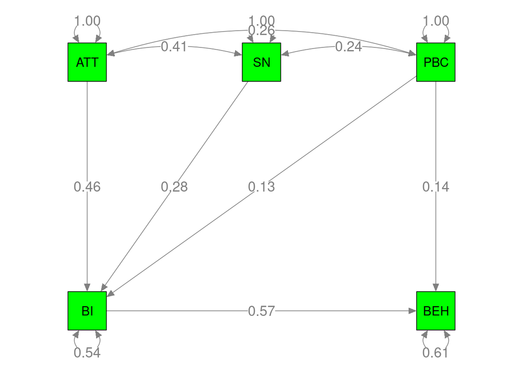

```r
## Plot the fitted model
plot(random2a, col="green")
```

- We may fit a model with equal coefficients by using the same label.

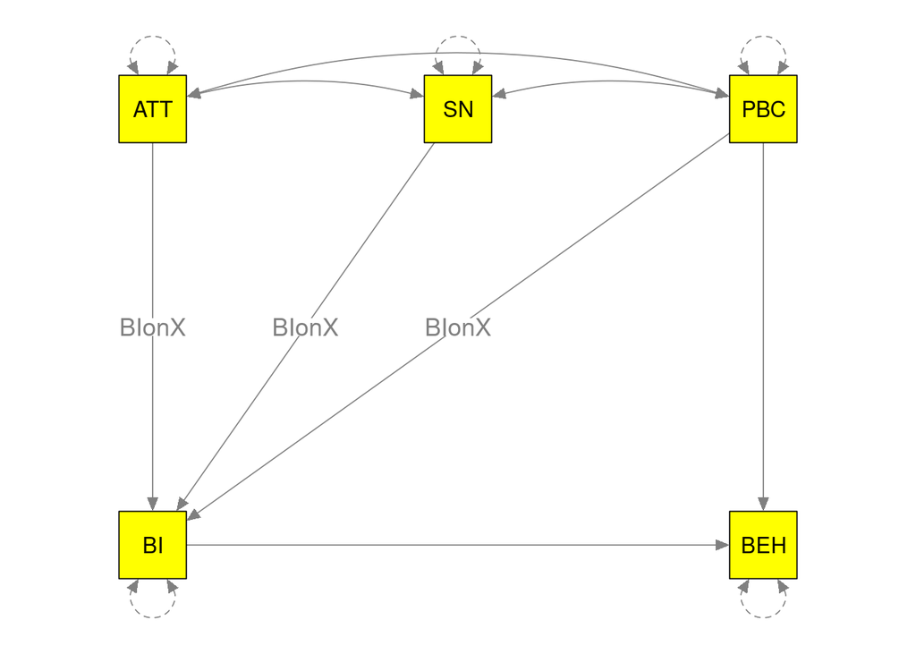

```r
## A model with equal path coefficients from the predictors to the mediator
model2 <- "## Same label on the path coefficients
          BI ~ BIonX*ATT + BIonX*SN + BIonX*PBC
          BEH ~ BI + PBC

          ## Fix the variances of the predictors at 1
          ATT ~~ 1*ATT
          SN ~~ 1*SN
          PBC ~~ 1*PBC

          ## Allow the predictors correlated
          ATT ~~ SN
          ATT ~~ PBC
          SN ~~ PBC
"

## Plot the model using the semPlot package
plot(model2, col="yellow")
```

```r
## Convert the lavaan syntax into the RAM specification
RAM2 <- lavaan2RAM(model2, obs.variables=obs.variables, A.notation="on", S.notation="with")
RAM2
```

```
## $A
##     ATT         SN          PBC            BI            BEH
## ATT "0"         "0"         "0"            "0"           "0"
## SN  "0"         "0"         "0"            "0"           "0"
## PBC "0"         "0"         "0"            "0"           "0"
## BI  "0.1*BIonX" "0.1*BIonX" "0.1*BIonX"    "0"           "0"
## BEH "0"         "0"         "0.1*BEHonPBC" "0.1*BEHonBI" "0"
##
## $S
##     ATT            SN            PBC            BI             BEH
## ATT "1"            "0*ATTwithSN" "0*ATTwithPBC" "0"            "0"
## SN  "0*ATTwithSN"  "1"           "0*SNwithPBC"  "0"            "0"
## PBC "0*ATTwithPBC" "0*SNwithPBC" "1"            "0"            "0"
## BI  "0"            "0"           "0"            "0.5*BIwithBI" "0"
## BEH "0"            "0"           "0"            "0"            "0.5*BEHwithBEH"
##
## $F
##     ATT SN PBC BI BEH
## ATT   1  0   0  0   0
## SN    0  1   0  0   0
## PBC   0  0   1  0   0
## BI    0  0   0  1   0
## BEH   0  0   0  0   1
##
## $M
##   ATT SN PBC BI BEH
## 1   0  0   0  0   0
```

```r
## Fit the proposed model
random2b <- tssem2(random1, RAM=RAM2, model.name="Same path to BI")
summary(random2b)
```

```
##
## Call:
## wls(Cov = pooledS, aCov = aCov, n = tssem1.obj$total.n, RAM = RAM,
##     Amatrix = Amatrix, Smatrix = Smatrix, Fmatrix = Fmatrix,
##     diag.constraints = diag.constraints, cor.analysis = cor.analysis,
##     intervals.type = intervals.type, mx.algebras = mx.algebras,
##     mxModel.Args = mxModel.Args, subset.variables = subset.variables,
##     model.name = model.name, suppressWarnings = suppressWarnings,
##     silent = silent, run = run)
##
## 95% confidence intervals: z statistic approximation
## Coefficients:
##             Estimate Std.Error    lbound    ubound z value Pr(>|z|)
## BEHonBI     0.630660  0.065292  0.502690  0.758631  9.6591   <2e-16 ***
## BEHonPBC    0.045729  0.076366 -0.103946  0.195403  0.5988   0.5493
## BIonX       0.292690  0.011983  0.269203  0.316177 24.4246   <2e-16 ***
## ATTwithPBC  0.253992  0.029905  0.195379  0.312605  8.4932   <2e-16 ***
## SNwithPBC   0.219691  0.023075  0.174466  0.264917  9.5209   <2e-16 ***
## ATTwithSN   0.474822  0.037690  0.400951  0.548694 12.5980   <2e-16 ***
## ---
## Signif. codes:  0 '***' 0.001 '**' 0.01 '*' 0.05 '.' 0.1 ' ' 1
##
## Goodness-of-fit indices:
##                                                 Value
## Sample size                                11349.0000
## Chi-square of target model                    39.7122
## DF of target model                             4.0000
## p value of target model                        0.0000
## Number of constraints imposed on "Smatrix"     0.0000
## DF manually adjusted                           0.0000
## Chi-square of independence model            1117.1822
## DF of independence model                      10.0000
## RMSEA                                          0.0280
## RMSEA lower 95% CI                             0.0205
## RMSEA upper 95% CI                             0.0363
## SRMR                                           0.0707
## TLI                                            0.9194
## CFI                                            0.9677
## AIC                                           31.7122
## BIC                                            2.3647
## OpenMx status1: 0 ("0" or "1": The optimization is considered fine.
## Other values indicate problems.)
```

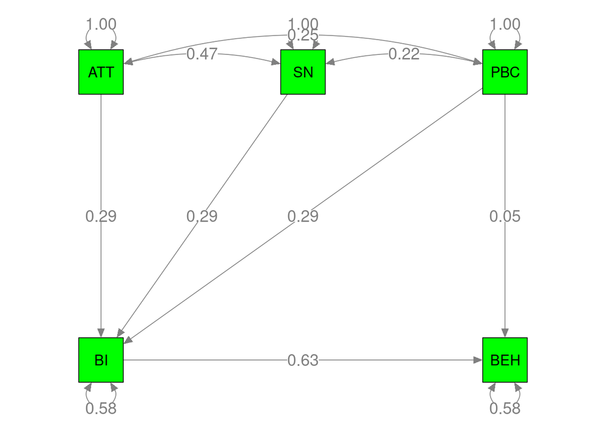

```r
## Plot the fitted model
plot(random2b, col="green")
```

```r
## Compare the two models
anova(random2a, random2b)
```

```
##               base      comparison ep  minus2LL df      AIC   diffLL diffdf
## 1 Free paths to BI            <NA>  8  4.247247 -8 20.24725       NA     NA
## 2 Free paths to BI Same path to BI  6 39.712241 -6 51.71224 35.46499      2
##              p
## 1           NA
## 2 1.990098e-08
```

- Functions of parameters, e.g., $R^2$, direct, and indirect effects, can be computed. A likelihood-based confidence interval (LBCI) can be computed on these functions (Neale & Miller, 1997[^10]).

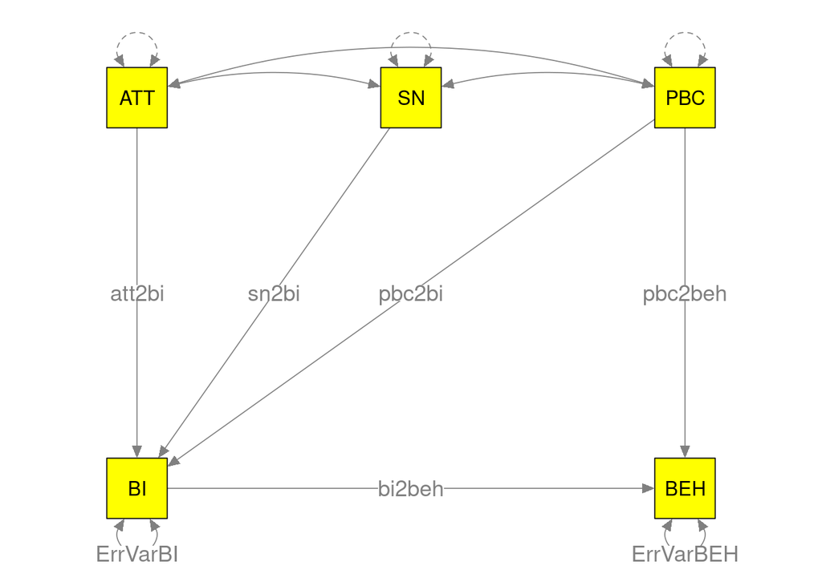

```r
model3 <- "BI ~ att2bi*ATT + sn2bi*SN + pbc2bi*PBC
          BEH ~ bi2beh*BI + pbc2beh*PBC

          ## Fix the variances of the predictors at 1
          ATT ~~ 1*ATT
          SN ~~ 1*SN
          PBC ~~ 1*PBC

          ## Allow the predictors correlated
          ATT ~~ SN
          ATT ~~ PBC
          SN ~~ PBC

          ## Label the error variances to calculate the R^2.
          BI ~~ ErrVarBI*BI
          BEH ~~ ErrVarBEH*BEH

          ## Define the R^2
          R2_BI   := 1 - ErrVarBI
          R2_BEH  := 1 - ErrVarBEH

          ## Define the indirect effects
          Ind_att := att2bi*bi2beh
          Ind_sn  := sn2bi*bi2beh
          Ind_pbc := pbc2beh*bi2beh

          ## Define the sum of the indirect effects
          Sum_ind := Ind_att + Ind_sn + Ind_pbc

          ## Define the direct effect
          Dir_eff := pbc2beh

          ## Define the total effect
          Tot_eff := Sum_ind + Dir_eff
"

## Plot the model using the semPlot package
plot(model3, col="yellow")
```

```r
## Convert the lavaan syntax into the RAM specification
RAM3 <- lavaan2RAM(model3, obs.variables=obs.variables, A.notation="on", S.notation="with")
RAM3
```

```
## $A
##     ATT          SN          PBC           BI           BEH
## ATT "0"          "0"         "0"           "0"          "0"
## SN  "0"          "0"         "0"           "0"          "0"
## PBC "0"          "0"         "0"           "0"          "0"
## BI  "0.1*att2bi" "0.1*sn2bi" "0.1*pbc2bi"  "0"          "0"
## BEH "0"          "0"         "0.1*pbc2beh" "0.1*bi2beh" "0"
##
## $S
##     ATT            SN            PBC            BI             BEH
## ATT "1"            "0*ATTwithSN" "0*ATTwithPBC" "0"            "0"
## SN  "0*ATTwithSN"  "1"           "0*SNwithPBC"  "0"            "0"
## PBC "0*ATTwithPBC" "0*SNwithPBC" "1"            "0"            "0"
## BI  "0"            "0"           "0"            "0.5*ErrVarBI" "0"
## BEH "0"            "0"           "0"            "0"            "0.5*ErrVarBEH"
##
## $F
##     ATT SN PBC BI BEH
## ATT   1  0   0  0   0
## SN    0  1   0  0   0
## PBC   0  0   1  0   0
## BI    0  0   0  1   0
## BEH   0  0   0  0   1
##
## $M
##   ATT SN PBC BI BEH
## 1   0  0   0  0   0
##
## $mxalgebras
## $mxalgebras$R2_BI
## mxAlgebra 'R2_BI'
## $formula:  1 - ErrVarBI
## $result: (not yet computed) <0 x 0 matrix>
## dimnames: NULL
##
## $mxalgebras$R2_BEH
## mxAlgebra 'R2_BEH'
## $formula:  1 - ErrVarBEH
## $result: (not yet computed) <0 x 0 matrix>
## dimnames: NULL
```

[output cut: 21 more lines]

```
## $formula:  Ind_att + Ind_sn + Ind_pbc
## $result: (not yet computed) <0 x 0 matrix>
## dimnames: NULL
##
## $mxalgebras$Dir_eff
## mxAlgebra 'Dir_eff'
## $formula:  pbc2beh
## $result: (not yet computed) <0 x 0 matrix>
## dimnames: NULL
##
## $mxalgebras$Tot_eff
## mxAlgebra 'Tot_eff'
## $formula:  Sum_ind + Dir_eff
## $result: (not yet computed) <0 x 0 matrix>
## dimnames: NULL
```

```r
## Fit the proposed model
## Add "diag.constraints=TRUE" to get the parameter estimates on the error variances
## Add "intervals.type="LB" to get the likelihood-based CIs of the functions of the parameters
random2c <- tssem2(random1, RAM=RAM3, diag.constraints=TRUE, intervals.type="LB")
summary(random2c)
```

```
##
## Call:
## wls(Cov = pooledS, aCov = aCov, n = tssem1.obj$total.n, RAM = RAM,
##     Amatrix = Amatrix, Smatrix = Smatrix, Fmatrix = Fmatrix,
##     diag.constraints = diag.constraints, cor.analysis = cor.analysis,
##     intervals.type = intervals.type, mx.algebras = mx.algebras,
##     mxModel.Args = mxModel.Args, subset.variables = subset.variables,
##     model.name = model.name, suppressWarnings = suppressWarnings,
##     silent = silent, run = run)
##
## 95% confidence intervals: Likelihood-based statistic
## Coefficients:
##               Estimate Std.Error      lbound      ubound z value Pr(>|z|)
## bi2beh      0.57067716        NA  0.46095087  0.68187002      NA       NA
## pbc2beh     0.13694751        NA -0.00060901  0.27084347      NA       NA
## att2bi      0.45629081        NA  0.37899483  0.53148314      NA       NA
## pbc2bi      0.13493388        NA  0.06861805  0.19939918      NA       NA
## sn2bi       0.28068390        NA  0.18721624  0.36860032      NA       NA
## ErrVarBEH   0.60584078        NA  0.49265062  0.70286725      NA       NA
## ErrVarBI    0.53959881        NA  0.46830570  0.60445828      NA       NA
## ATTwithPBC  0.25566692        NA  0.19613718  0.31551347      NA       NA
## SNwithPBC   0.23720738        NA  0.19174700  0.28265108      NA       NA
## ATTwithSN   0.41288426        NA  0.33436126  0.49141716      NA       NA
##
## mxAlgebras objects (and their 95% likelihood-based CIs):
##                     lbound   Estimate    ubound
## R2_BI[1,1]    3.955417e-01 0.46040119 0.5316943
## R2_BEH[1,1]   2.971327e-01 0.39415922 0.5073494
## Ind_att[1,1]  1.997555e-01 0.26039474 0.3262642
## Ind_sn[1,1]   1.034323e-01 0.16017989 0.2209250
## Ind_pbc[1,1] -3.690857e-05 0.07815282 0.1411438
## Sum_ind[1,1]  4.181323e-01 0.49872745 0.5869770
## Dir_eff[1,1] -6.090066e-04 0.13694751 0.2708435
## Tot_eff[1,1]  4.548045e-01 0.63567497 0.8080028
##
## Goodness-of-fit indices:
##                                                 Value
## Sample size                                11349.0000
## Chi-square of target model                     4.2472
## DF of target model                             2.0000
## p value of target model                        0.1196
## Number of constraints imposed on "Smatrix"     2.0000
## DF manually adjusted                           0.0000
## Chi-square of independence model            1117.1822
## DF of independence model                      10.0000
## RMSEA                                          0.0100
## RMSEA lower 95% CI                             0.0000
## RMSEA upper 95% CI                             0.0233
## SRMR                                           0.0345
## TLI                                            0.9899
## CFI                                            0.9980
## AIC                                            0.2472
## BIC                                          -14.4265
## OpenMx status1: 0 ("0" or "1": The optimization is considered fine.
## Other values indicate problems.)
```

## OSMASEM

- The one-stage MASEM (OSMASEM; Jak & Cheung, 2020[^11]) can be used to model categorical and continuous moderators.
- Let us illustrate the procedures with the percentage of female (`Female` in the dataset) as a moderator.

### Data preparation

- We have to transform the list of correlation matrices into a dataframe before the analysis.
- There are some studies without info on gender composition. We have to remove them before the analysis.

```r
## Convert the correlation matrices into a dataframe, which is required in osmasem()
df <- Cor2DataFrame(Scalco17)

## Center female for numerical stability
df$data$Female <- scale(df$data$Female, scale=FALSE)

## Display the data
df$data$Female
```

```
##              [,1]
##  [1,] -25.0755556
##  [2,] -22.5755556
##  [3,]  -0.5755556
##  [4,] -20.5755556
##  [5,] -22.5755556
##  [6,]  -0.5755556
##  [7,] -20.5755556
##  [8,]          NA
##  [9,]  25.7744444
## [10,]  25.7744444
## [11,]  28.9844444
## [12,]          NA
## [13,]  10.4244444
## [14,]  15.0244444
## [15,]          NA
## [16,]  -0.3755556
## [17,]  14.4244444
## [18,]          NA
## [19,]   9.4244444
## [20,]          NA
## [21,]  -5.5755556
## [22,]  13.7244444
## [23,] -25.0755556
## attr(,"scaled:center")
## [1] 50.57556
```

```r
## Compute an indicator on data present
(subset.rows <- !is.na(df$data$Female))
```

```
##        [,1]
##  [1,]  TRUE
##  [2,]  TRUE
##  [3,]  TRUE
##  [4,]  TRUE
##  [5,]  TRUE
##  [6,]  TRUE
##  [7,]  TRUE
##  [8,] FALSE
##  [9,]  TRUE
## [10,]  TRUE
## [11,]  TRUE
## [12,] FALSE
## [13,]  TRUE
## [14,]  TRUE
## [15,] FALSE
## [16,]  TRUE
## [17,]  TRUE
## [18,] FALSE
## [19,]  TRUE
## [20,] FALSE
## [21,]  TRUE
## [22,]  TRUE
## [23,]  TRUE
```

### A model without any moderator

- We fit the structural equation model without any moderator. Since we will compare models with and without a moderator, we need to ensure that data with `NA` in `Female` are removed in both models.
- As the results are similar to those in the TSSEM approach, we do not discuss them again.

```r
fit1 <- osmasem(model.name="No moderator", RAM=RAM1, data=df, subset.rows=subset.rows)
summary(fit1)
```

```
## Summary of No moderator
##
## free parameters:
##          name  matrix row col   Estimate  Std.Error A    z value     Pr(>|z|)
## 1     BIonATT      A0  BI ATT  0.4567774 0.04156374    10.989804 0.000000e+00
## 2      BIonSN      A0  BI  SN  0.3075574 0.05741414     5.356823 8.469804e-08
## 3     BIonPBC      A0  BI PBC  0.0915987 0.03577377     2.560499 1.045220e-02
## 4    BEHonPBC      A0 BEH PBC  0.1536578 0.08054615     1.907699 5.643013e-02
## 5     BEHonBI      A0 BEH  BI  0.5891568 0.06973850     8.448085 0.000000e+00
## 6   ATTwithSN      S0  SN ATT  0.4412665 0.04395465    10.039131 0.000000e+00
## 7  ATTwithPBC      S0 PBC ATT  0.2668365 0.03213706     8.303077 0.000000e+00
## 8   SNwithPBC      S0 PBC  SN  0.2485289 0.02514240     9.884850 0.000000e+00
## 9      Tau1_1 vecTau1   1   1 -3.4268608 0.35843964    -9.560496 0.000000e+00
## 10     Tau1_2 vecTau1   2   1 -4.1274221 0.38258953   -10.788121 0.000000e+00
## 11     Tau1_3 vecTau1   3   1 -4.3357300 0.35677493   -12.152563 0.000000e+00
## 12     Tau1_4 vecTau1   4   1 -4.3709308 0.66696053    -6.553508 5.620104e-11
## 13     Tau1_5 vecTau1   5   1 -4.7431786 0.44767548   -10.595127 0.000000e+00
## 14     Tau1_6 vecTau1   6   1 -3.4320423 0.35874561    -9.566786 0.000000e+00
## 15     Tau1_7 vecTau1   7   1 -4.5767621 0.77967675    -5.870076 4.355944e-09
## 16     Tau1_8 vecTau1   8   1 -4.4380139 0.39551085   -11.220967 0.000000e+00
## 17     Tau1_9 vecTau1   9   1 -3.8101965 0.64759941    -5.883570 4.015099e-09
## 18    Tau1_10 vecTau1  10   1 -3.7645528 0.72354876    -5.202901 1.962010e-07
##
## To obtain confidence intervals re-run with intervals=TRUE
##
## Model Statistics:
##                |  Parameters  |  Degrees of Freedom  |  Fit (-2lnL units)
##        Model:             18                    110             -132.6125
##    Saturated:             65                     63                    NA
## Independence:             20                    108                    NA
## Number of observations/statistics: 9961/128
##
## Information Criteria:
##       |  df Penalty  |  Parameters Penalty  |  Sample-Size Adjusted
## AIC:      -352.6125              -96.61254                -96.54374
## BIC:     -1145.3201               33.10325                -24.09810
## To get additional fit indices, see help(mxRefModels)
## timestamp: 2023-02-24 19:24:55
## Wall clock time: 0.206718 secs
## optimizer:  SLSQP
## OpenMx version number: 2.20.7
## Need help?  See help(mxSummary)
```

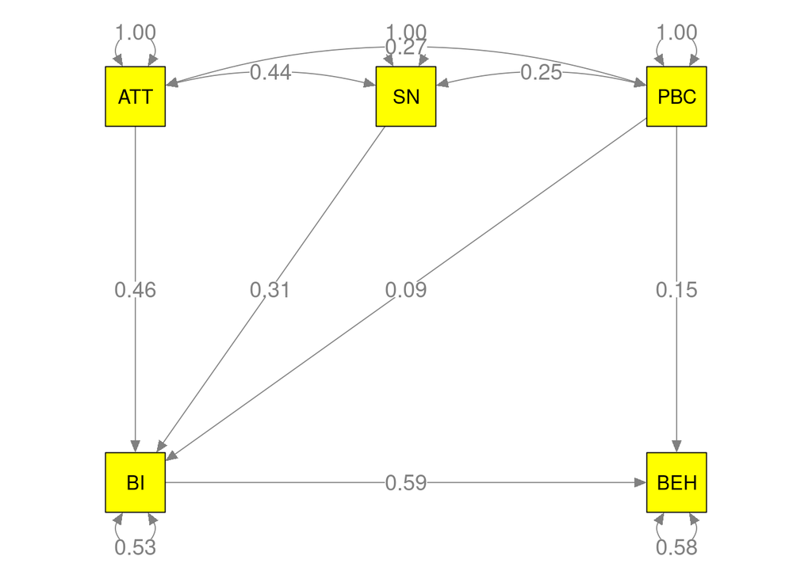

```r
plot(fit1, col="yellow")
```

### A model with a moderator

- We create a matrix to indicate which parameters are modeled by `Female`.
- By default, the moderator models *all* free paths in the `A` matrix. We may modify it if you only want to moderate some paths.

```r
## Display the A matrix
RAM1$A
```

```
##     ATT           SN           PBC            BI            BEH
## ATT "0"           "0"          "0"            "0"           "0"
## SN  "0"           "0"          "0"            "0"           "0"
## PBC "0"           "0"          "0"            "0"           "0"
## BI  "0.1*BIonATT" "0.1*BIonSN" "0.1*BIonPBC"  "0"           "0"
## BEH "0"           "0"          "0.1*BEHonPBC" "0.1*BEHonBI" "0"
```

```r
## A matrix indicating which paths to be modeled by `Female`
A1 <- create.modMatrix(RAM=RAM1, output="A", mod="Female")
A1
```

```
##     ATT             SN              PBC             BI              BEH
## ATT "0"             "0"             "0"             "0"             "0"
## SN  "0"             "0"             "0"             "0"             "0"
## PBC "0"             "0"             "0"             "0"             "0"
## BI  "0*data.Female" "0*data.Female" "0*data.Female" "0"             "0"
## BEH "0"             "0"             "0*data.Female" "0*data.Female" "0"
```

```r
## We may modify it if we only want to model the path from PBC to BEH
## Renamed A1_bi2beh to A1_pbc2beh for consistency
A1_pbc2beh <- A1
A1_pbc2beh[4, ] <- A1_pbc2beh[5, 4] <- "0"
A1_pbc2beh
```

```
##     ATT SN  PBC             BI  BEH
## ATT "0" "0" "0"             "0" "0"
## SN  "0" "0" "0"             "0" "0"
## PBC "0" "0" "0"             "0" "0"
## BI  "0" "0" "0"             "0" "0"
## BEH "0" "0" "0*data.Female" "0" "0"
```

```r
## Ax=A1: Use A1 as the moderator
fit2 <- osmasem(model.name="Female as moderator", RAM=RAM1, Ax=A1, data=df,
                subset.rows=subset.rows)
summary(fit2)
```

```
## Summary of Female as moderator
##
## free parameters:
##          name  matrix row col      Estimate   Std.Error A      z value
## 1     BIonATT      A0  BI ATT  0.4551867712 0.041372204    11.00223651
## 2      BIonSN      A0  BI  SN  0.3164790912 0.057535029     5.50063320
## 3     BIonPBC      A0  BI PBC  0.0890176139 0.035070323     2.53826049
## 4    BEHonPBC      A0 BEH PBC  0.1428006401 0.081718219     1.74747617
## 5     BEHonBI      A0 BEH  BI  0.5667880503 0.066520296     8.52052809
## 6   ATTwithSN      S0  SN ATT  0.4417812709 0.044123256    10.01243586
## 7  ATTwithPBC      S0 PBC ATT  0.2669105233 0.032220028     8.28399402
## 8   SNwithPBC      S0 PBC  SN  0.2489397796 0.025278376     9.84793406
## 9   BIonATT_1      A1  BI ATT -0.0009928088 0.002097445    -0.47334190
## 10   BIonSN_1      A1  BI  SN  0.0008534566 0.002658773     0.32099637
## 11  BIonPBC_1      A1  BI PBC  0.0018981580 0.001706745     1.11215103
## 12 BEHonPBC_1      A1 BEH PBC -0.0001745320 0.004042028    -0.04317932
## 13  BEHonBI_1      A1 BEH  BI  0.0047032650 0.002969018     1.58411449
## 14     Tau1_1 vecTau1   1   1 -3.4188270823 0.358250068    -9.54313031
## 15     Tau1_2 vecTau1   2   1 -4.1227190231 0.382337809   -10.78292266
## 16     Tau1_3 vecTau1   3   1 -4.3295124623 0.356866484   -12.13202320
## 17     Tau1_4 vecTau1   4   1 -4.8303255664 0.704889490    -6.85259978
## 18     Tau1_5 vecTau1   5   1 -4.7323249124 0.445489944   -10.62274240
## 19     Tau1_6 vecTau1   6   1 -3.4074017800 0.363349333    -9.37775709
## 20     Tau1_7 vecTau1   7   1 -5.0423861432 0.862041812    -5.84935217
## 21     Tau1_8 vecTau1   8   1 -4.5239887438 0.396501385   -11.40976783
## 22     Tau1_9 vecTau1   9   1 -3.8882802041 0.650342627    -5.97881800
## 23    Tau1_10 vecTau1  10   1 -3.9348874327 0.776639797    -5.06655395
##        Pr(>|z|)
## 1  0.000000e+00
## 2  3.784297e-08
## 3  1.114050e-02
## 4  8.055478e-02
## 5  0.000000e+00
## 6  0.000000e+00
## 7  2.220446e-16
## 8  0.000000e+00
## 9  6.359693e-01
## 10 7.482131e-01
## 11 2.660732e-01
## 12 9.655586e-01
```

[output cut: 16 more lines]

```
##        Model:             23                    105             -139.2425
##    Saturated:             65                     63                    NA
## Independence:             20                    108                    NA
## Number of observations/statistics: 9961/128
##
## Information Criteria:
##       |  df Penalty  |  Parameters Penalty  |  Sample-Size Adjusted
## AIC:      -349.2425              -93.24253               -93.131435
## BIC:     -1105.9180               72.50542                -0.585202
## To get additional fit indices, see help(mxRefModels)
## timestamp: 2023-02-24 19:24:56
## Wall clock time: 0.8062253 secs
## optimizer:  SLSQP
## OpenMx version number: 2.20.7
## Need help?  See help(mxSummary)
```

```r
## Compare the models with and without the moderator
anova(fit2, fit1)
```

```
##                  base   comparison ep  minus2LL  df       AIC   diffLL diffdf
## 1 Female as moderator         <NA> 23 -139.2425 105 -93.24253       NA     NA
## 2 Female as moderator No moderator 18 -132.6125 110 -96.61254 6.629999      5
##           p
## 1        NA
## 2 0.2496435
```

```r
## Intercepts when `Female` is zero (mean)
mxEval(A0, fit2$mx.fit)
```

```
##           ATT        SN        PBC        BI BEH
## ATT 0.0000000 0.0000000 0.00000000 0.0000000   0
## SN  0.0000000 0.0000000 0.00000000 0.0000000   0
## PBC 0.0000000 0.0000000 0.00000000 0.0000000   0
## BI  0.4551868 0.3164791 0.08901761 0.0000000   0
## BEH 0.0000000 0.0000000 0.14280064 0.5667881   0
```

```r
## Slopes when `Female` increases one unit
mxEval(A1, fit2$mx.fit)
```

```
##               ATT           SN          PBC          BI BEH
## ATT  0.0000000000 0.0000000000  0.000000000 0.000000000   0
## SN   0.0000000000 0.0000000000  0.000000000 0.000000000   0
## PBC  0.0000000000 0.0000000000  0.000000000 0.000000000   0
## BI  -0.0009928088 0.0008534566  0.001898158 0.000000000   0
## BEH  0.0000000000 0.0000000000 -0.000174532 0.004703265   0
```

# Calculating multivariate effect sizes

- It is not straightforward to calculate effect sizes for complicated models.
- The `metaSEM` package includes some functions to facilitate this process using an SEM approach (Cheung, 2018)[^12]. See [link 1](https://stats.stackexchange.com/questions/256053/variance-of-cohens-d-for-within-subjects-designs/) and [link 2](https://stats.stackexchange.com/questions/108248/calculating-effect-sizes-and-standard-errors-for-the-difference-between-two-stan/) for two examples.

## Multiple-treatment studies (MTS)

- MTS is used when there are more than treatment groups, for example, one control group with two treatment groups. Effect sizes calculated are not independent because the same control group is used. Gleser and Olkin (2009)[^13] derived formulas to calculate the standardized mean differences and their sampling covariance matrix for multiple treatment studies under the assumption of homogeneity of the variances.
- The following figure shows an SEM approach to estimate MTS. The effect sizes are:
  - $SMD_1 = \frac{\mu_{T1} - \mu_{C} }{\sigma}$
  - $SMD_2 = \frac{\mu_{T2} - \mu_{C} }{\sigma}$
- We may make the homogeneity assumption by using $\sigma=\sigma_{C}=\sigma_{T1}=\sigma_{T2}$. However, we may also use the control group as the standardizer, that is, $\sigma=\sigma_{C}$, if there are reasons to believe the variances are not homogeneous.
- The SEM approach will calculate the effect sizes and their sampling covariance matrix with the Delta method.

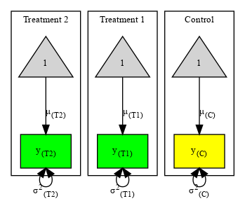

```r
## Optional: only for ease of reference
gp.names <- c("Control", "Treatment 1", "Treatment 2")

## Sample means for groups 1 to 3
m <- c(5, 7, 9)
names(m) <- gp.names
m
```

```
##     Control Treatment 1 Treatment 2
##           5           7           9
```

```r
## Sample variances
v <- c(10, 11, 12)
names(v) <- gp.names
v
```

```
##     Control Treatment 1 Treatment 2
##          10          11          12
```

```r
## Sample sizes
n <- c(50, 52, 53)
names(n) <- gp.names
n
```

```
##     Control Treatment 1 Treatment 2
##          50          52          53
```

```r
## Assuming homogeneity of variances
smdMTS(m, v, n, homogeneity="var")
```

```
## $y
##      y2_1      y3_1
## 0.5979628 1.1960156
##
## $V
##            y2_1       y3_1
## y2_1 0.03979647 0.02200887
## y3_1 0.02200887 0.04290577
```

```r
## Not assuming homogeneity of variances
## The SD of the first group is used as the standardizer
smdMTS(m, v, n, homogeneity = "none")
```

```
## $y
##      y2_1      y3_1
## 0.6277002 1.2554949
##
## $V
##            y2_1       y3_1
## y2_1 0.04447739 0.02758260
## y3_1 0.02758260 0.05777168
```

## Multiple-endpoint studies (MES)

- MES is used when there is more than one outcome variable, e.g., mathematics and language performance. Gleser and Olkin (2009) derived formulas to calculate the standardized mean differences and their sampling covariance matrix for multiple end-point studies under the assumption of homogeneity of the covariance matrix.
- An SEM approach can be used to calculate effect sizes on MES with or without the assumption of homogeneity of covariance matrix.
- The following figure shows an SEM approach to estimate MTS. The effect sizes are:
  - $SMD_1 = \frac{\mu1_{T1} - \mu1_{C} }{\sigma_1}$
  - $SMD_2 = \frac{\mu2_{T2} - \mu2_{C} }{\sigma_2}$
- $\sigma_1$ and $\sigma_2$ can be estimated with or without the homogeneity assumption covariance matrix.

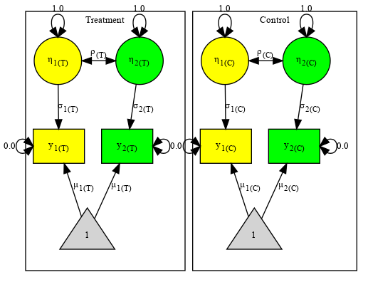

```r
## Optional: only for ease of reference
var.names <- c("Math", "Lang")

## Sample means for the two constructs in Group 1
m1 <- c(2.5, 4.5)
names(m1) <- var.names
m1
```

```
## Math Lang
##  2.5  4.5
```

```r
## Sample means for the two constructs in Group 2
m2 <- c(3, 5)
names(m2) <- var.names
m2
```

```
## Math Lang
##    3    5
```

```r
## Sample covariance matrix in Group 1
V1 <- matrix(c(3, 2, 2, 3), ncol=2)
dimnames(V1) <- list(var.names, var.names)
V1
```

```
##      Math Lang
## Math    3    2
## Lang    2    3
```

```r
## Sample covariance matrix in Group 2
V2 <- matrix(c(3.5, 2.1, 2.1, 3.5), ncol=2)
dimnames(V2) <- list(var.names, var.names)
V2
```

```
##      Math Lang
## Math  3.5  2.1
## Lang  2.1  3.5
```

```r
## Sample size in Group 1
n1 <- 20

## Sample size in Group 2
n2 <- 25

## SMD with the assumption of homogeneity of covariance matrix
smdMES(m1, m2, V1, V2, n1, n2, homogeneity="cov")
```

```
## $y
##        y1        y2
## 0.2713273 0.2713273
##
## $V
##            y1         y2
## y1 0.08768779 0.05479937
## y2 0.05479937 0.08768779
```

```r
## SMD with the assumption of homogeneity of correlation matrix
smdMES(m1, m2, V1, V2, n1, n2, homogeneity="cor")
```

```
## $y
##        y1        y2
## 0.2890961 0.2890961
##
## $V
##            y1         y2
## y1 0.09843189 0.06151767
## y2 0.06151767 0.09843190
```

```r
## SMD without any assumption of homogeneity
smdMES(m1, m2, V1, V2, n1, n2, homogeneity="none")
```

```
## $y
##        y1        y2
## 0.2836107 0.2836107
##
## $V
##            y1         y2
## y1 0.09531548 0.06009389
## y2 0.06009389 0.09531548
```

## A general model to compute effect sizes

- Let us use the previous example in MASEM as an illustration. Suppose we want to calculate the sum of the indirect effects and direct effect as two effect sizes in a multivariate meta-analysis (this may not be a good idea due to the missing data and other reasons; see Cheung, 2022[^14]).

```r
## Take one correlation matrix as an example
(R1 <- Scalco17$data[23])
```

```
## $`Zagata, 2012`
##       ATT    SN   PBC    BI   BEH
## ATT 1.000 0.391 0.388 0.518 0.239
## SN  0.391 1.000 0.222 0.497 0.272
## PBC 0.388 0.222 1.000 0.388 0.204
## BI  0.518 0.497 0.388 1.000 0.338
## BEH 0.239 0.272 0.204 0.338 1.000
```

```r
(n1 <- Scalco17$n[23])
```

```
## [1] 1054
```

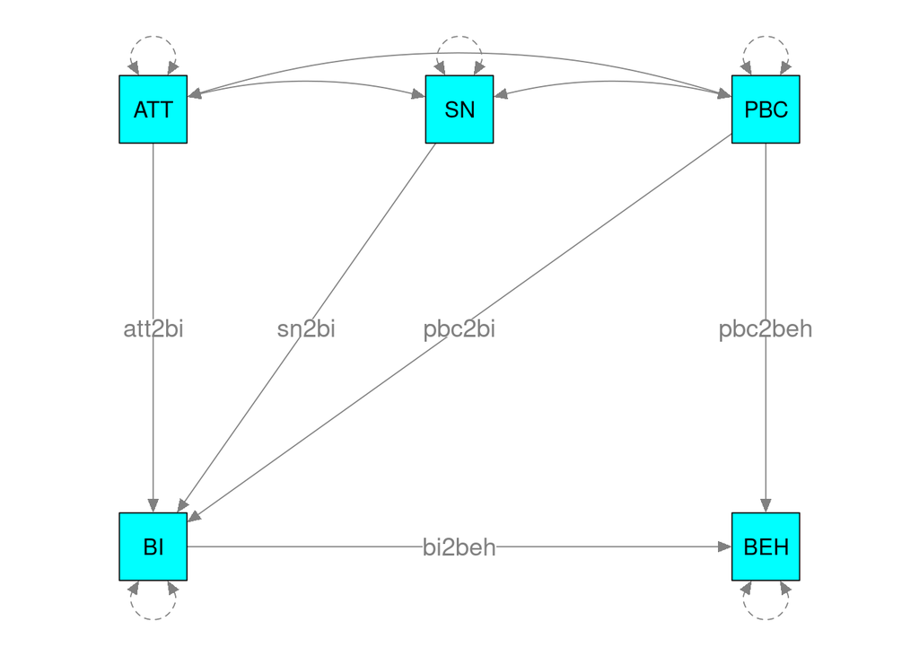

```r
model4 <- "BI ~ att2bi*ATT + sn2bi*SN + pbc2bi*PBC
          BEH ~ bi2beh*BI + pbc2beh*PBC

          ## Fix the variances of the predictors at 1
          ATT ~~ 1*ATT
          SN ~~ 1*SN
          PBC ~~ 1*PBC

          ## Allow the predictors correlated
          ATT ~~ SN
          ATT ~~ PBC
          SN ~~ PBC

          ## Define the sum of the indirect effects
          Sum_ind := att2bi*bi2beh + sn2bi*bi2beh + pbc2beh*bi2beh

          ## Define the direct effect
          Dir_eff := pbc2beh
"

## Plot the model using the semPlot package
plot(model4, col="cyan")
```

```r
calEffSizes(model4, Cov=R1, n=n1)
```

```
## $ES
##    Sum_ind    Dir_eff
## 0.22273508 0.08576783
##
## $VCOV
##              Sum_ind      Dir_eff
## Sum_ind 5.340225e-04 2.074234e-05
## Dir_eff 2.074234e-05 9.823312e-04
```

# Other useful functions

- There are several useful functions in the [metaSEM](https://github.com/mikewlcheung/metasem) package:
  - `meta`: Fit univariate and multivariate meta-analyses.
  - `meta3`: Fit a three-level meta-analysis.
  - `metaFIML`: Fit univariate and multivariate meta-analyses with missing covariates with the full information maximum likelihood (FIML) estimation.
  - `indirectEffect`: Calculate standardized and unstandardized indirect effect in mediation analysis.

# References

[^1]: Cheung, M. W.-L. (2015). metaSEM: An R package for meta-analysis using structural equation modeling. *Frontiers in Psychology*, *5*(1521). https://doi.org/10.3389/fpsyg.2014.01521
[^2]: Cheung, M. W.-L. (2014). Fixed- and random-effects meta-analytic structural equation modeling: Examples and analyses in R. *Behavior Research Methods*, *46*(1), 29–40. https://doi.org/10.3758/s13428-013-0361-y
[^3]: Cheung, M. W.-L. (2015). *Meta-analysis: A structural equation modeling approach*. John Wiley & Sons, Inc. http://dx.doi.org/10.1002/9781118957813
[^4]: Cheung, M. W.-L. (2019). Some reflections on combining meta-analysis and structural equation modeling. *Research Synthesis Methods*, *10*(1), 15–22. https://doi.org/10.1002/jrsm.1321
[^5]: Cheung, M. W.-L., & Chan, W. (2005). Meta-analytic structural equation modeling: A two-stage approach. *Psychological Methods*, 10(1), 40–64. https://doi.org/10.1037/1082-989X.10.1.40
[^6]: Cheung, M. W.-L., & Chan, W. (2009). A two-stage approach to synthesizing covariance matrices in meta-analytic structural equation modeling. *Structural Equation Modeling: A Multidisciplinary Journal*, *16*(1), 28–53. https://doi.org/10.1080/10705510802561295
[^7]: Cheung, M. W.-L., & Cheung, S. F. (2016). Random-effects models for meta-analytic structural equation modeling: Review, issues, and illustrations. *Research Synthesis Methods*, *7*(2), 140–155. https://doi.org/10.1002/jrsm.1166
[^8]: Cheung, M. W.-L., & Hafdahl, A. R. (2016). Special issue on meta-analytic structural equation modeling: Introduction from the guest editors. *Research Synthesis Methods*, *7*(2), 112–120. https://doi.org/10.1002/jrsm.1212
[^9]: Scalco, A., Noventa, S., Sartori, R., & Ceschi, A. (2017). Predicting organic food consumption: A meta-analytic structural equation model based on the theory of planned behavior. *Appetite*, *112*, 235–248. https://doi.org/10.1016/j.appet.2017.02.007
[^10]: Neale, M. C., & Miller, M. B. (1997). The use of likelihood-based confidence intervals in genetic models. *Behavior Genetics*, *27*(2), 113–120. https://doi.org/10.1023/A:1025681223921
[^11]: Jak, S., & Cheung, M. W.-L. (2020). Meta-analytic structural equation modeling with moderating effects on SEM parameters. *Psychological Methods*, *25*(4), 430–455. https://doi.org/10.1037/met0000245
[^12]: Computing multivariate effect sizes and their sampling covariance matrices with structural equation modeling: Theory, examples, and computer simulations. *Frontiers in Psychology*, *9*(1387). https://doi.org/10.3389/fpsyg.2018.01387
[^13]: Gleser, L. J., & Olkin, I. (2009). Stochastically dependent effect sizes. In H. Cooper, L. V. Hedges, & J. C. Valentine (Eds.), *The handbook of research synthesis and meta-analysis*. (2nd ed., pp. 357-376). New York: Russell Sage Foundation.
[^14]: Cheung, M. W.-L. (2022). Synthesizing indirect effects in mediation models with meta-analytic methods. *Alcohol and Alcoholism*, *57*(1), 5–15. https://doi.org/10.1093/alcalc/agab044